# Exercice 5 : personnalisation du format PDF

Télécharger le code source du document Exercice_5_PDF.Rmd et l’enregistrer dans un dossier pertinent.

Ouvrir le fichier dans votre éditeur de texte favori.

Compiler le fichier et ouvrir le document compilé.

**Fermer le document PDF, car R Markdown sera incapable d’effectuer des modifications à celui-ci s’il est toujours ouvert au moment de la prochaine compilation.**

Dans l’en-tête du document, ajouter un `:` après l’option `pdf_document`. Le `:` indique au compilateur qu’une option de niveau inférieur suivra.

Faire un retour à la ligne et une tabulation, puis ajouter l’option `toc: TRUE` sous `pdf_document:`.

L’en-tête résultante est illustrée ci-bas. Attention! Le respect de l’indentation et des `:` est essentiel.

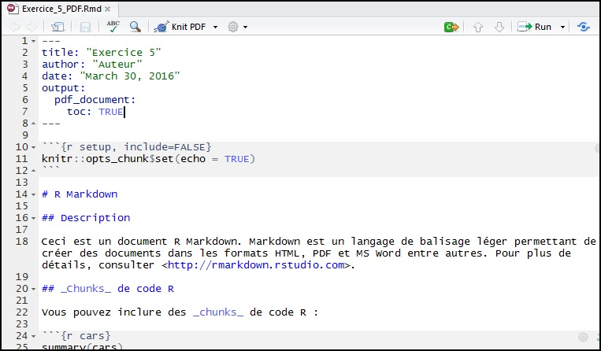

Compiler le document à nouveau, puis observer les changements (indice : table des matières).

**Fermer le document PDF, car R Markdown sera incapable d’effectuer des modifications à celui-ci s’il est toujours ouvert au moment de la prochaine compilation.**

Ajouter l’option `toc_depth: 1` sous `toc: TRUE` :

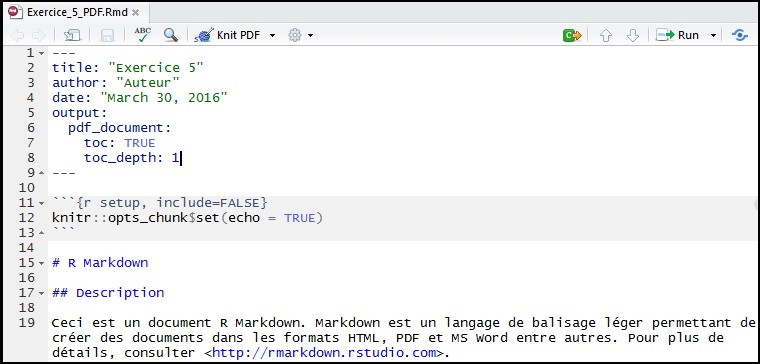

Compiler le document à nouveau, puis observer les changements.

**À nouveau, après avoir consulté les modifications, fermer le document PDF, car R Markdown sera incapable d’effectuer des modifications à celui-ci s’il est toujours ouvert au moment de la prochaine compilation.**

De la même façon que la ligne précédente, ajouter la ligne `number_sections: TRUE` à l’en-tête, compiler le résultat, et observer les changements.

Fermer le document PDF.

De la même façon que la ligne précédente, ajouter la ligne `highlight: espresso` à l’en-tête, compiler le résultat, et observer les changements.

Fermer le document PDF.

Sur une nouvelle ligne, ajouter l’option `fontsize: 5pt`. Cette ligne ne devrait pas avoir d’indentation :

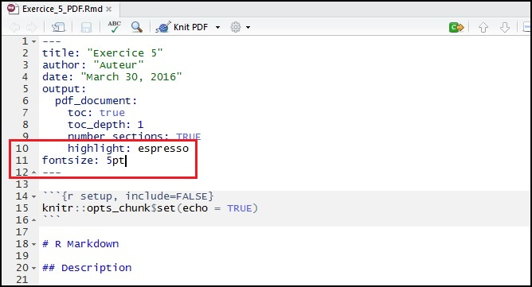

Compiler le résultat, et observer les changements.

Fermer le document PDF.

De la même façon que la ligne précédente, ajouter la ligne `geometry: margin=2in` à l’en-tête, compiler le résultat, et observer les changements.

Fermer le document PDF.

De la même façon que la ligne précédente, ajouter la ligne `lang: fr` à l’en-tête, compiler le résultat, et observer les changements.

Fermer le document PDF.

Vous êtes tellement satisfaits de votre travail que vous désirez le publier sous forme de livre? De la même façon que la ligne précédente, ajouter la ligne `documentclass: book` à l’en-tête, compiler le résultat, et observer les changements.

Fermer le document PDF.

Vous voulez que les liens de type URL soient plus évidents? De la même façon que la ligne précédente, ajouter la ligne `urlcolor: blue` à l’en-tête, compiler le résultat, et observer les changements.

Le résultat final du code source devrait être le suivant :

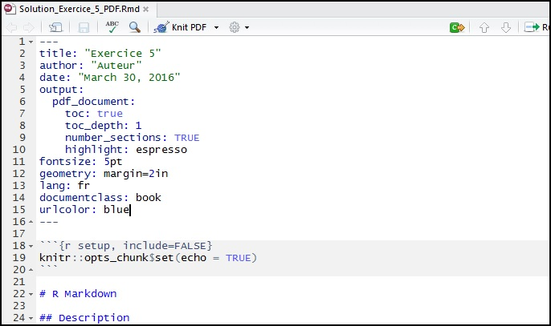

Pour un guide plus complet des fonctionnalités PDF, consulter la page à ce sujet sur le site de R Markdown : [Options du format PDF en R Markdown](http://rmarkdown.rstudio.com/pdf_document_format.html)